# 파괴될지언정 패배하지 않는 인간의 품격: 헤밍웨이 ‘노인과 바다’ 서평

고전

결과가 아닌 과정에서 증명되는 인간의 존엄성. 헤밍웨이 특유의 절제된 문체 속에 담긴 노인 산티아고의 불굴의 정신을 탐구합니다.

Published

April 28, 2026

[figure not shown]

노인과 바다: 고독하지만 당당한 항해

노력의 결실이 한순간에 뼈만 남은 채 사라진다면, 당신은 그것을 실패라고 부르겠습니까? 어니스트 헤밍웨이의 정수가 담긴 걸작 **《노인과 바다》**는 우리에게 승리와 패배의 정의를 다시 묻습니다. 84일간의 불운 끝에 마주한 거대한 청새치, 그리고 그 결실을 지키기 위한 고독한 사투. 오늘은 산티아고 노인의 삶을 통해 인간이 지켜내야 할 마지막 ’품격’에 대해 이야기해보려 합니다.

### 핵심 요약: 바다 위에서 증명한 인간의 정의

1. **절제된 문장 속의 거대한 진실**: 헤밍웨이의 ’빙산 이론’이 극명하게 드러나는 간결하고 힘 있는 서사.
2. **형제이자 적, 청새치와의 사투**: 자연을 정복의 대상이 아닌, 경외와 존중을 담은 대결의 상대로 마주하는 태도.
3. **영적인 승리**: 비록 손에는 뼈만 남았을지언정, 끝내 굴복하지 않은 인간 정신의 위대함.

### 상세 분석: 산티아고가 지키려 했던 것은 무엇인가

#### 1. 하드보일드, 감정을 걷어낸 자리에 남은 의지

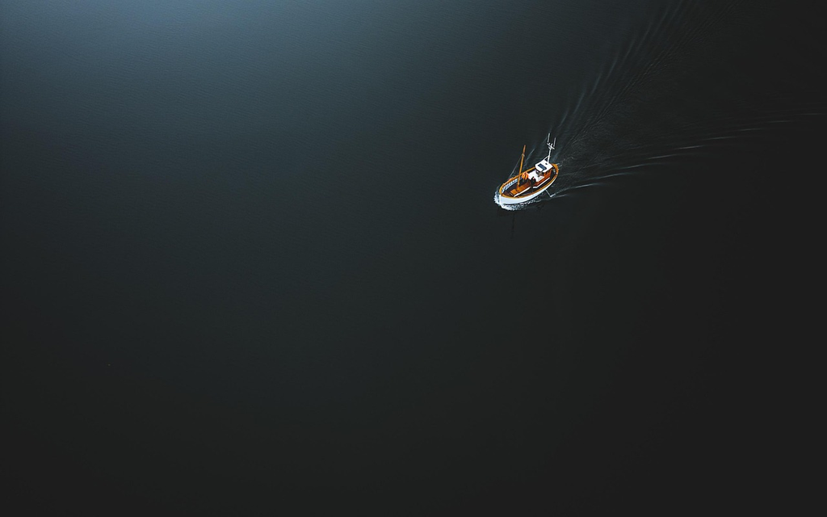

먼 바다로 나가는 고독한 도전

헤밍웨이는 불필요한 수식어를 배제하는 ‘하드보일드’ 문체의 대가입니다. 노인 산티아고의 고통을 묘사할 때도 그는 감상에 젖지 않습니다. 84일 동안 고기를 잡지 못해 ’살라오(최악의 불운)’라 불리는 상황에서도 노인은 묵묵히 낚싯줄을 정비합니다. 이러한 절제된 태도는 오히려 노인이 가진 내면의 단단함을 더욱 돋보이게 합니다. 운명을 한탄하는 대신, 자신이 해야 할 일을 정확히 수행하는 숙련된 어부의 자부심이야말로 그를 지탱하는 힘입니다.

#### 2. “나는 너를 사랑하고 존중한다”: 적과의 동료애

[figure not shown]

거대한 물고기와의 치열한 사투

노인은 자신을 사지로 몰아넣는 거대한 청새치를 향해 “형제여”라고 부릅니다. 이는 단순한 사냥꾼의 외침이 아닙니다. 자신을 한계까지 밀어붙이는 고난(청새치)을 증오하는 것이 아니라, 그 고귀한 생명력에 경의를 표하며 온 힘을 다해 맞서는 어부의 예우입니다. 노인에게 이 싸움은 상대를 죽이기 위한 도구가 아니라, 스스로가 인간으로서 얼마나 견딜 수 있는지, 얼마나 정당하게 투쟁할 수 있는지 증명하는 성스러운 의식과 같습니다.

#### 3. 뼈만 남은 귀환, 그러나 패배하지 않은 삶

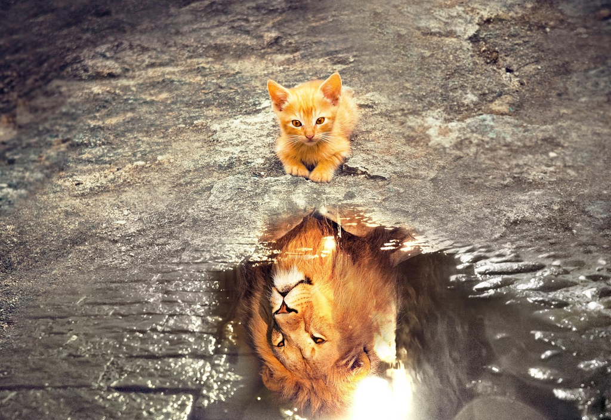

사자 꿈을 꾸며 맞이하는 평온한 아침

상어 떼의 공격으로 청새치는 뼈만 남게 됩니다. 육체는 만신창이가 되었고 전유물은 사라졌습니다. 하지만 노인은 “인간은 파괴될지언정 패배하지 않는다”고 말합니다. 세상은 뼈의 크기로 성공을 가늠할지 모르지만, 헤밍웨이는 낚싯줄을 놓지 않았던 노인의 손바닥에 새겨진 굳은살에 집중합니다. 모든 것을 잃고 돌아와 다시 사자 꿈을 꾸는 노인의 모습은, 외부의 결과가 아닌 내면의 투쟁에서 승리한 자만이 누릴 수 있는 고귀한 평온을 보여줍니다.

### 마무리: 당신의 바다에도 사자가 살고 있나요?

우리의 삶 역시 거대한 바다와 같습니다. 때로는 수개월의 노력이 상어 떼(뜻밖의 시련)에 의해 순식간에 사라지기도 합니다. 하지만 산티아고 노인이 우리에게 남긴 유산은 명확합니다. 결과가 우리를 배신할지라도, 끝까지 품위를 잃지 않고 마주하는 그 과정 자체가 인간의 위대함이라는 사실입니다.

오늘 하루, 당신이 지켜내려 했던 ’사자’와 같은 자부심은 무엇이었나요? 비록 눈앞의 결과가 뼈만 남았을지라도 실망하지 마세요. 당신은 여전히 파괴될 수 있으나, 결코 패배하지 않은 위엄 있는 존재입니다.

#노인과바다 #헤밍웨이 #고전서평 #문학리뷰 #인생책추천 #인문학 #인간의존엄성 #하드보일드 #필독도서 #자기계발

### 💬 댓글을 남겨주세요